# Over Representation Analysis

This analysis will seek to determine if there are genes from pre-defined sets (e.g. belonging to a specific GO term or KEGG pathway) are over-represented in our dataset (https://www.ncbi.nlm.nih.gov/geo/query/acc.cgi?acc=GSE63061). This dataset consists of individuals with Alzheimer’s disease, mild cognitive impairment, and controls.

```r
#library(clusterProfiler)
library(GEOquery)
#library(GSEABase)
#library(GOstats)
#library(KEGG.db)
library(limma)
library(org.Hs.eg.db)
library(sva)
```

Load the transcriptomic data.

```r
gsm.expr <- getGEO("GSE63061")
```

[output not shown]

```r
gsm.expr <- gsm.expr[[1]]
exprGEO <- exprs(gsm.expr)
```

Get the phenotype data.

```r
pheno <- pData(phenoData(gsm.expr))
status <- pheno$characteristics_ch1
status <- gsub("status: ","", as.character(status))
fstatus <- factor(status)
levels(fstatus)<-gsub(" ", "", levels(fstatus))
```

Get the variables that will be used to build the models.

```r
age <- substr(pheno$characteristics_ch1.2, 6,7)
age <- as.numeric(age)
sex <- pheno$characteristics_ch1.3
phenodat <- data.frame(fstatus, age, sex)
```

Build the models (with and without the individuals’ status).

```r
#build models
mod0 <- model.matrix( ~ age+sex, data = phenodat)
mod <- model.matrix( ~ fstatus+age+sex, data = phenodat)
```

Compute surrogate variables for batch effects.

```r
svobj <- sva(exprGEO, mod, mod0, n.sv=2)
```

```
Number of significant surrogate variables is:  2
Iteration (out of 5 ):1  2  3  4  5
```

```r
design <- model.matrix(~ 0+fstatus+sex+age+svobj$sv[,1]+svobj$sv[,2])
colnames(design) <- c(levels(fstatus),"age","sex", "sva1","sva2")
```

Fit the model for the desired contrast.

```r
fit <- lmFit(exprGEO, design)
contrast.matrix <- makeContrasts(AD-CTL, MCI-CTL, AD-MCI, levels=design)

fit2 <- contrasts.fit(fit, contrast.matrix)
fit2 <- eBayes(fit2)
```

The object fit2 contains the results of the transcriptome-wise association analysis. For enrichment analysis, we first obtain the p-values of association for the contrast of Alzheimer’s disease against controls. These are the associations for each of the Illumina probes.

```r
results <- fit2$p.value
head(results)
```

```
              Contrasts
                   AD - CTL  MCI - CTL    AD - MCI
  ILMN_1343291 0.0001343099 0.23838365 0.012397242
  ILMN_1343295 0.1349217169 0.46002556 0.492158315
  ILMN_1651209 0.1706294304 0.27616550 0.836459962
  ILMN_1651210 0.2716501412 0.02707706 0.225797561
  ILMN_1651221 0.4511555267 0.26407231 0.675401774
  ILMN_1651228 0.0171718691 0.64695073 0.005701243
```

Filter to the relevant probes for this analysis, i.e. comparing individuals with Alzheimer’s vs those in the control group.

```r
pvalues <- results[,"AD - CTL"]
head(pvalues)
```

```
ILMN_1343291 ILMN_1343295 ILMN_1651209 ILMN_1651210 ILMN_1651221 ILMN_1651228
0.0001343099 0.1349217169 0.1706294304 0.2716501412 0.4511555267 0.0171718691
```

Adjust the p-values to reduce the false discovery rate and filter to only the significant probes. This leaves us with 819 probes.

```r
pAdj <- p.adjust(pvalues, "fdr")
psig <- pAdj[pAdj < 0.01]

length(psig)
```

```
[1] 819
```

```r
head(psig)
```

```
ILMN_1343291 ILMN_1651254 ILMN_1651776 ILMN_1652073 ILMN_1652085 ILMN_1652806
6.176532e-03 6.650025e-06 7.517934e-04 1.013183e-10 1.479804e-03 7.091283e-05
```

Map the Illumina probes to their genes.

```r
genesIDs <- as.character(fData(gsm.expr)$ILMN_Gene)
names(genesIDs) <- rownames(gsm.expr)
psigAnnot <- data.frame(genesIDs=genesIDs[names(psig)], pvalAdj=psig,stringsAsFactors=FALSE)

head(psigAnnot)
```

|  | genesIDs | pvalAdj |
| --- | --- | --- |
| ILMN_1343291 | EEF1A1 | 6.176532e-03 |
| ILMN_1651254 | LPP | 6.650025e-06 |
| ILMN_1651776 | FHOD1 | 7.517934e-04 |
| ILMN_1652073 | LOC653658 | 1.013183e-10 |
| ILMN_1652085 | MPHOSPH10 | 1.479804e-03 |
| ILMN_1652806 | ATP5J | 7.091283e-05 |

Using the org.Hs.eg.db database, retrieve all the gene symbols and the entrez identifiers annotated in the human genome.

```r
geneUniverse <- select(org.Hs.eg.db, keys=genes, columns=c("ENTREZID"), keytype="SYMBOL")
```

[output not shown]

Get the entrez identifiers for the genes with DE transcripts.

```r
mappedgenes <- psigAnnot$genesIDs
mappedgenes <- intersect(mappedgenes,geneUniverse$SYMBOL)
selmappedgenes <- geneUniverse$SYMBOL%in%mappedgenes
mappedgenesIds <- geneUniverse$ENTREZID[selmappedgenes]

length(mappedgenesIds)
```

```
[1] 509
```

```r
head(mappedgenesIds)
```

```
[1] "20"  "34"  "37"  "101" "199" "204"
```

Get the parameters that will be passed to Hhpergeometric tests for GO term association.

```r
params <- new(
  "GOHyperGParams",
  geneIds=mappedgenesIds,
  universeGeneIds=geneUniverse$ENTREZID,
  annotation="org.Hs.eg.db",
  ontology="BP",
  pvalueCutoff=0.05,
  conditional=FALSE,
  testDirection="over"
)
```

Compute the p-values for over-representation of each GO term.

```r
hgOver <- hyperGTest(params)
hgOver
```

```
Gene to GO BP  test for over-representation
4851 GO BP ids tested (786 have p < 0.05)
Selected gene set size: 476
    Gene universe size: 18866
    Annotation package: org.Hs.eg
```

See the GO terms with that are the most statistically significant.

```r
summary(hgOver)[c(1:5),]
```

|  | GOBPID | Pvalue | OddsRatio | ExpCount | Count | Size | Term |
| --- | --- | --- | --- | --- | --- | --- | --- |
| 1 | GO:0016071 | 1.325933e-23 | 4.384587 | 22.455210 | 80 | 890 | mRNA metabolic process |
| 2 | GO:0006614 | 2.150582e-22 | 15.633639 | 2.649210 | 29 | 105 | SRP-dependent cotranslational protein targeting to membrane |
| 3 | GO:0006613 | 6.892960e-22 | 14.848714 | 2.750133 | 29 | 109 | cotranslational protein targeting to membrane |
| 4 | GO:0000184 | 9.664225e-22 | 13.677130 | 3.027669 | 30 | 120 | nuclear-transcribed mRNA catabolic process, nonsense-mediated decay |
| 5 | GO:0006402 | 2.362395e-21 | 6.338848 | 9.486696 | 49 | 376 | mRNA catabolic process |

Gene sets forming GO terms are not disjoint and overlapping GO terms will have correlating enrichment. Use a conditional test and generate another report.

```r
conditional(params) <- TRUE
hgOverCond <- hyperGTest(params)
summary(hgOver)[c(1:3),]
```

|  | GOBPID | Pvalue | OddsRatio | ExpCount | Count | Size | Term |
| --- | --- | --- | --- | --- | --- | --- | --- |
| 1 | GO:0016071 | 1.325933e-23 | 4.384587 | 22.455210 | 80 | 890 | mRNA metabolic process |
| 2 | GO:0006614 | 2.150582e-22 | 15.633639 | 2.649210 | 29 | 105 | SRP-dependent cotranslational protein targeting to membrane |
| 3 | GO:0006613 | 6.892960e-22 | 14.848714 | 2.750133 | 29 | 109 | cotranslational protein targeting to membrane |

We can gain further insights using the using the KEGGdatabase. Get the mapping of human genes (with entrez identifiers) to the KEGG pathways identifiers.

```r
frame <- toTable(org.Hs.egPATH)
keggframeData <- data.frame(frame$path_id, frame$gene_id)
head(keggframeData)
```

|  | frame.path_id | frame.gene_id |
| --- | --- | --- |
| 1 | 04610 | 2 |
| 2 | 00232 | 9 |
| 3 | 00983 | 9 |
| 4 | 01100 | 9 |
| 5 | 00232 | 10 |
| 6 | 00983 | 10 |

```r
keggFrame <- KEGGFrame(keggframeData, organism="Homo sapiens")
gsc.KEGG <- GeneSetCollection(keggFrame, setType = KEGGCollection())
gsc.KEGG
```

```
GeneSetCollection
  names: 00010, 00020, ..., 05416 (229 total)
  unique identifiers: 124, 125, ..., 1525 (5868 total)
  types in collection:
    geneIdType: KEGGFrameIdentifier (1 total)
    collectionType: KEGGCollection (1 total)
```

Perform an enrichment analysis for each of these pathways, defining a new set of parameters that will be passed to the hypergeometric test function hyperGTest

[output not shown]

[output cut: 5 more lines]

We see that 15 KEGG pathways are significantly enriched in transcriptomic differences between Alzheimer’s cases and controls.

With enrichKEGG from clusterProfiler, we can obtain similar results as before, with less amount of code but less control.

```r
res.enrich <- enrichKEGG(gene = mappedgenesIds, organism = 'hsa', pvalueCutoff = 0.05)
res.enrich[, 1:7]
```

|  | ID | Description | GeneRatio | BgRatio | pvalue | p.adjust | qvalue |
| --- | --- | --- | --- | --- | --- | --- | --- |
| hsa03010 | hsa03010 | Ribosome | 37/270 | 158/8111 | 8.944052e-22 | 2.262845e-19 | 2.099498e-19 |
| hsa00190 | hsa00190 | Oxidative phosphorylation | 26/270 | 133/8111 | 1.442085e-13 | 1.824238e-11 | 1.692553e-11 |
| hsa05171 | hsa05171 | Coronavirus disease - COVID-19 | 33/270 | 232/8111 | 8.764286e-13 | 7.391215e-11 | 6.857670e-11 |
| hsa05012 | hsa05012 | Parkinson disease | 31/270 | 249/8111 | 1.513097e-10 | 9.570339e-09 | 8.879491e-09 |
| hsa05020 | hsa05020 | Prion disease | 31/270 | 273/8111 | 1.538644e-09 | 7.785540e-08 | 7.223530e-08 |
| hsa05016 | hsa05016 | Huntington disease | 32/270 | 306/8111 | 6.477228e-09 | 2.731231e-07 | 2.534073e-07 |
| hsa05014 | hsa05014 | Amyotrophic lateral sclerosis | 35/270 | 364/8111 | 1.089937e-08 | 3.939343e-07 | 3.654976e-07 |
| hsa04932 | hsa04932 | Non-alcoholic fatty liver disease | 21/270 | 155/8111 | 3.665982e-08 | 1.159367e-06 | 1.075676e-06 |
| hsa03040 | hsa03040 | Spliceosome | 19/270 | 150/8111 | 4.896241e-07 | 1.376388e-05 | 1.277031e-05 |
| hsa03050 | hsa03050 | Proteasome | 10/270 | 46/8111 | 1.998092e-06 | 5.055174e-05 | 4.690259e-05 |

[output cut: 8 more lines]

Create a dotplot to show the number of genes mapped in each of the pathways.

```
wrong orderBy parameter; set to default `orderBy = "x"`
```

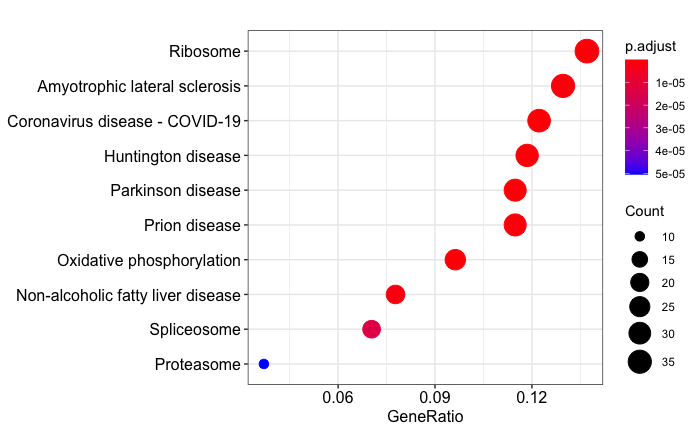

```r
dotplot(res.enrich)
```